# Simple Bayesian Modeling with PyMC

Refer to https://github.com/hangwl/DataScience/tree/master/BayesianML for some Bayesian theory.

```python
import pymc as pm
import arviz as az
import numpy as np
import matplotlib.pyplot as plt
```

```
WARNING (pytensor.tensor.blas): Using NumPy C-API based implementation for BLAS functions.
```

```python
data = np.genfromtxt('conversion_data.csv', delimiter=',', skip_header=1)
```

```python
# conversion_data.csv
'''
Pageviews Version A,Conversions Version A,Pageviews Version B,Conversions Version B
1000,200,1000,250
1200,220,1200,270
1500,240,1500,280
1800,260,1800,300
2000,270,2000,320
2200,280,2200,340
2500,290,2500,360
2800,300,2800,380
3000,310,3000,400
3200,320,3200,420
3500,330,3500,440
3800,340,3800,460
4000,350,4000,480
4200,360,4200,500
4500,370,4500,520
4800,380,4800,540
5000,390,5000,560
5200,400,5200,580
5500,410,5500,600
5800,420,5800,620
6000,430,6000,640
'''
```

```python
with pm.Model() as model:
    # Priors for the conversion rates of Version A and Version B
    p_A = pm.Beta('p_A', alpha=1, beta=1)
    p_B = pm.Beta('p_B', alpha=1, beta=1)

    # Likelihood of the data
    obs_A = pm.Binomial('obs_A', n=data[:,0], p=p_A, observed=data[:,1])
    obs_B = pm.Binomial('obs_B', n=data[:,2], p=p_B, observed=data[:,3])

    # Difference in conversion rates between Version A and Version B
    delta = pm.Deterministic('delta', p_B - p_A)

    # Metric for comparison
    pm.Deterministic('effect_size', delta / np.sqrt((p_A*(1-p_A) + p_B*(1-p_B))/2))

    # Sample from the posterior distribution
    # trace = pm.sample(5000, tune=1000, chains=4)
    trace = pm.sample()
```

```
Auto-assigning NUTS sampler...
Initializing NUTS using jitter+adapt_diag...
Multiprocess sampling (4 chains in 4 jobs)
NUTS: [p_A, p_B]
```

100.00% [8000/8000 00:02<00:00 Sampling 4 chains, 0 divergences]

```
Sampling 4 chains for 1_000 tune and 1_000 draw iterations (4_000 + 4_000 draws total) took 15 seconds.
```

This code performs Bayesian A/B testing by specifying Beta priors for the conversion rates of Version A and Version B, and likelihood of the data using `pm.Binomial()`. The difference in conversion rates between the two versions is computed using `pm.Deterministic()`, and a metric for comparison is computed using the effect size. The posterior distribution is sampled using `pm.sample()`.

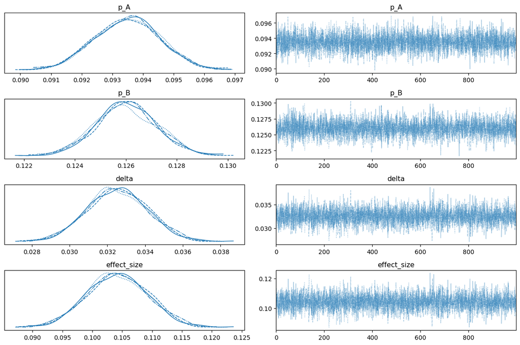

```python
az.plot_trace(trace)
plt.tight_layout()
```

The `az.plot_trace(trace)` function generates a plot of the posterior distribution of each parameter in the model, along with its corresponding trace plot. The trace plot shows how the parameter value changes as the MCMC sampling algorithm progresses. This plot is useful for diagnosing convergence of the MCMC chain and determining if the chain has adequately explored the posterior distribution. The posterior distribution plot shows the density of the posterior distribution for each parameter.

```
array([<Axes: title={'center': 'p_A'}>, <Axes: title={'center': 'p_B'}>],
      dtype=object)
```

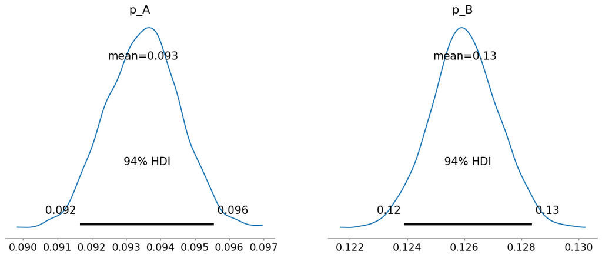

```python
az.plot_posterior(trace, var_names=['p_A', 'p_B'])
```

The `az.plot_posterior(trace, var_names=['p_A', 'p_B'])` function generates a plot of the posterior distribution for the parameters p_A and p_B. This plot shows the probability density of different values of p_A and p_B given the observed data and the prior distributions. The plot includes the mean of the posterior distribution and the 94% credible interval, which represents the range of values that contains 94% of the posterior density.